# DengAI

Oren Jalon

October 1, 2018

# PRELIMINARY DATA PREPARATION

This section includes importing the data, creating of new variables and establishing the dataframes for the initial analysis

### Import raw data

```r
dengue_features_test <- read.csv("D:/Google Drive/RYERSON/CKME 136/DengAI/DATASET/dengue_features_test.csv", header = TRUE, stringsAsFactors = FALSE)
dengue_features_train <- read.csv("D:/Google Drive/RYERSON/CKME 136/DengAI/DATASET/dengue_features_train.csv", header = TRUE, stringsAsFactors = FALSE)
dengue_labels_train <- read.csv("D:/Google Drive/RYERSON/CKME 136/DengAI/DATASET/dengue_labels_train.csv", header = TRUE, stringsAsFactors = FALSE)
submission_format <- read.csv("D:/Google Drive/RYERSON/CKME 136/DengAI/DATASET/submission_format.csv", header = TRUE, stringsAsFactors = FALSE)
```

### Convert week_start_date to date format

```r
dengue_features_test$week_start_date <- as.Date(dengue_features_test$week_start_date, "%Y-%m-%d")
dengue_features_train$week_start_date <- as.Date(dengue_features_train$week_start_date, "%Y-%m-%d")
```

### Convert city to factor

```r
dengue_features_test$city <- as.factor(dengue_features_test$city)
dengue_features_train$city <- as.factor(dengue_features_train$city)
```

### Rescale the variables so that it is all in Celcius and mm

```r
dengue_features_train$reanalysis_dew_point_temp_k <- dengue_features_train$reanalysis_dew_point_temp_k - 273.15
dengue_features_test$reanalysis_dew_point_temp_k <- dengue_features_test$reanalysis_dew_point_temp_k - 273.15

dengue_features_train$reanalysis_air_temp_k <- dengue_features_train$reanalysis_air_temp_k - 273.15
dengue_features_test$reanalysis_air_temp_k <- dengue_features_test$reanalysis_air_temp_k - 273.15

dengue_features_train$reanalysis_max_air_temp_k <- dengue_features_train$reanalysis_max_air_temp_k - 273.15
dengue_features_test$reanalysis_max_air_temp_k <- dengue_features_test$reanalysis_max_air_temp_k - 273.15

dengue_features_train$reanalysis_min_air_temp_k <- dengue_features_train$reanalysis_min_air_temp_k - 273.15
dengue_features_test$reanalysis_min_air_temp_k <- dengue_features_test$reanalysis_min_air_temp_k - 273.15

dengue_features_train$reanalysis_avg_temp_k <- dengue_features_train$reanalysis_avg_temp_k - 273.15
dengue_features_test$reanalysis_avg_temp_k <- dengue_features_test$reanalysis_avg_temp_k - 273.15

#!!!tdtr does not appear to be in Kelvin
# dengue_features_train$reanalysis_tdtr_k <- dengue_features_train$reanalysis_tdtr_k - 273.15
# dengue_features_test$reanalysis_tdtr_k <- dengue_features_test$reanalysis_tdtr_k - 273.15

summary(dengue_features_train$reanalysis_dew_point_temp_k)
```

```
##    Min. 1st Qu.  Median    Mean 3rd Qu.    Max.    NA's
##   16.49   20.97   22.49   22.10   23.31   25.30      10
```

```r
summary(dengue_features_train$reanalysis_air_temp_k)
```

```
##    Min. 1st Qu.  Median    Mean 3rd Qu.    Max.    NA's
##   21.49   24.51   25.50   25.55   26.68   29.05      10
```

```r
summary(dengue_features_train$reanalysis_max_air_temp_k)
```

```
##    Min. 1st Qu.  Median    Mean 3rd Qu.    Max.    NA's
##   24.65   27.85   29.25   30.28   32.35   40.85      10
```

```r
summary(dengue_features_train$reanalysis_min_air_temp_k)
```

```
##    Min. 1st Qu.  Median    Mean 3rd Qu.    Max.    NA's
##   13.75   20.75   23.05   22.57   24.75   26.75      10
```

```r
summary(dengue_features_train$reanalysis_avg_temp_k)
```

```
##    Min. 1st Qu.  Median    Mean 3rd Qu.    Max.    NA's
##   21.74   25.11   26.14   26.08   27.06   29.78      10
```

```r
summary(dengue_features_train$reanalysis_tdtr_k)
```

```
##    Min. 1st Qu.  Median    Mean 3rd Qu.    Max.    NA's
##   1.357   2.329   2.857   4.904   7.625  16.029      10
```

### Merge test and train set without the total_cases

```r
df <- rbind(dengue_features_train,dengue_features_test)
```

### Divide the test into sj and iq separately

```r
iq_features_test <- dengue_features_test[dengue_features_test$city == 'iq', ]
sj_features_test <- dengue_features_test[dengue_features_test$city == 'sj', ]
```

### Divide training sets into sj and iq separately

```r
iq_features_train <- dengue_features_train[dengue_features_train$city == 'iq', ]
sj_features_train <- dengue_features_train[dengue_features_train$city == 'sj', ]
```

### Divide the labels sets into sj and iq separately

```r
iq_labels_train <- dengue_labels_train[dengue_labels_train$city == 'iq', ]
sj_labels_train <- dengue_labels_train[dengue_labels_train$city == 'sj', ]
```

### Merge test and training sets separately for each city without total_cases

```r
sj <- rbind(sj_features_train,sj_features_test)
iq <- rbind(iq_features_train,iq_features_test)
```

### Merge train and label sets to include total_cases

```r
df_train_labels <- merge(dengue_features_train, dengue_labels_train, by=c("city","year","weekofyear"))
```

### Merge test and training sets separately for each city including total_cases

```r
sj_train_labels <- merge(sj_features_train, sj_labels_train, by=c("city","year","weekofyear"))
iq_train_labels <- merge(iq_features_train, iq_labels_train, by=c("city","year","weekofyear"))
```

# INITIAL & EXPLORATORY ANALYSIS

In this section, we summary the value of the data frames (together and by city). We also create the following graphs

1. Frequency histograms
2. Bivariate analysis - line graphs for time analysis
3. Bivariate analysis - scatterplot for total_cases by other variables
4. Wilcoxon test for test of means between cities

### Review summary stats for each city

```r
library(psych)
df_test.summary <- psych::describe(dengue_features_test, IQR=TRUE, quant=c(.25,.75) )
View(df_test.summary)
df_train.summary <- psych::describe(dengue_features_train, IQR=TRUE, quant=c(.25,.75) )
View(df_train.summary)

sj_train.summary <- psych::describe(sj_train_labels, IQR=TRUE, quant=c(.25,.75) )
View(sj_train.summary)

iq_train.summary <- psych::describe(iq_train_labels, IQR=TRUE, quant=c(.25,.75) )
View(iq_train.summary)


df.summary <- psych::describe(df, IQR=TRUE, quant=c(.25,.75))
View(df.summary)
sj.summary <- psych::describe(sj, IQR=TRUE, quant=c(.25,.75) )
View(sj.summary)
iq.summary <- psych::describe(iq, IQR=TRUE, quant=c(.25,.75) )
View(iq.summary)

summary(dengue_features_test$week_start_date)
```

```
##         Min.      1st Qu.       Median         Mean      3rd Qu.
## "2008-04-29" "2010-04-28" "2011-05-28" "2011-04-04" "2012-05-27"
##         Max.
## "2013-06-25"
```

```r
summary(dengue_features_train$week_start_date)
```

```
##         Min.      1st Qu.       Median         Mean      3rd Qu.
## "1990-04-30" "1997-04-28" "2002-05-28" "2001-07-09" "2005-11-26"
##         Max.
## "2010-06-25"
```

```r
summary(iq_features_train$week_start_date)
```

```
##         Min.      1st Qu.       Median         Mean      3rd Qu.
## "2000-07-01" "2002-12-30" "2005-06-28" "2005-06-28" "2007-12-26"
##         Max.
## "2010-06-25"
```

```r
summary(iq_features_test$week_start_date)
```

```
##         Min.      1st Qu.       Median         Mean      3rd Qu.
## "2010-07-02" "2011-03-31" "2011-12-28" "2011-12-28" "2012-09-24"
##         Max.
## "2013-06-25"
```

```r
summary(sj_features_train$week_start_date)
```

```
##         Min.      1st Qu.       Median         Mean      3rd Qu.
## "1990-04-30" "1994-10-27" "1999-04-26" "1999-04-26" "2003-10-23"
##         Max.
## "2008-04-22"
```

```r
summary(sj_features_test$week_start_date)
```

```
##         Min.      1st Qu.       Median         Mean      3rd Qu.
## "2008-04-29" "2009-07-28" "2010-10-25" "2010-10-25" "2012-01-23"
##         Max.
## "2013-04-23"
```

### GRAPH: Frequency histogram of all variables in training set (both cities together)

These graphs only include data from the training set as it includes total cases. Climate data across both training and test sets are below.

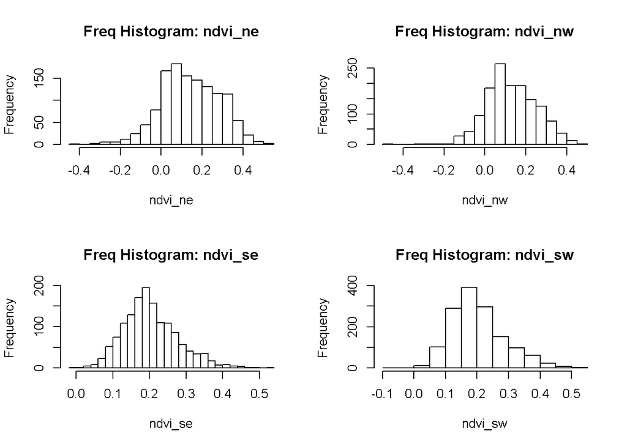

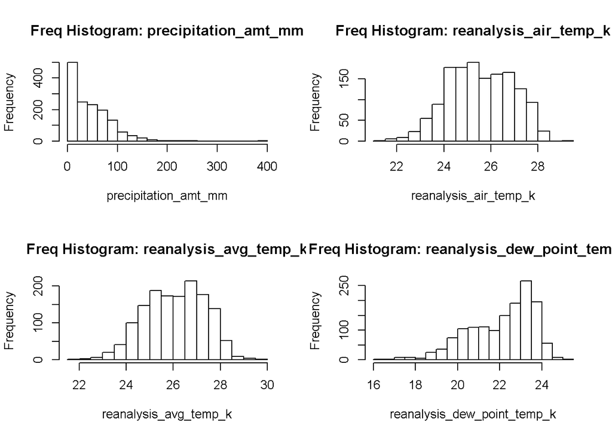

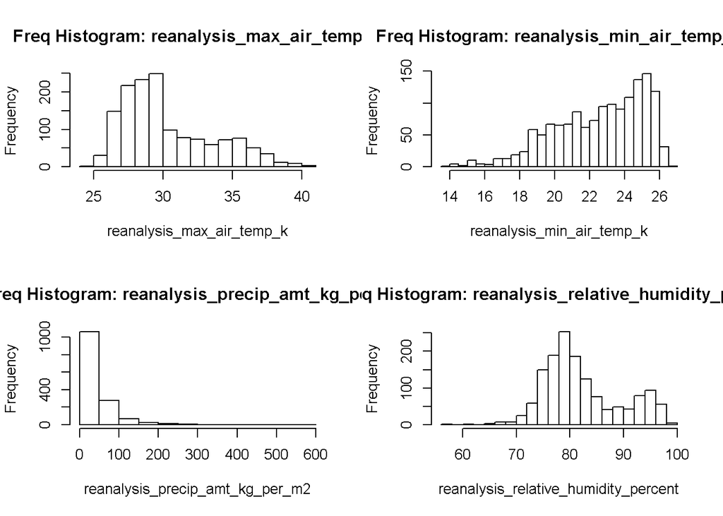

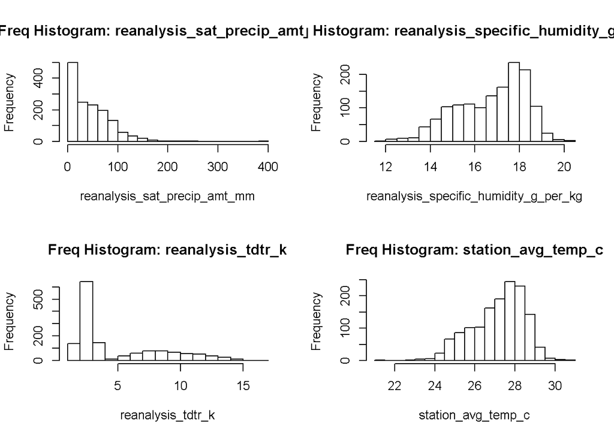

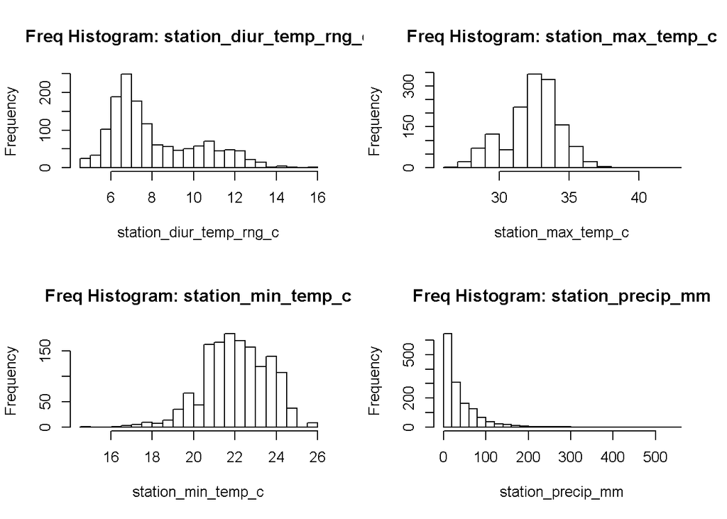

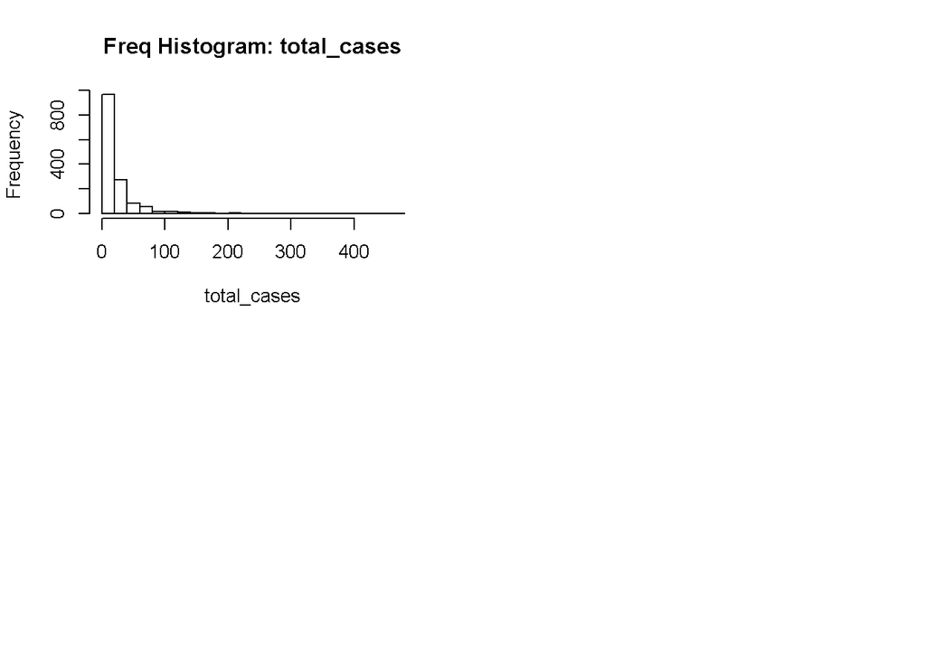

```r
#remove week_start_date for histogram

df_train_labels$week_start_date <- NULL

cnames <- colnames(df_train_labels)
par(mfrow=c(2,2))
for (i in 4:ncol(df_train_labels)) {
 hist(df_train_labels[,i],
      breaks = 20,
      main = paste("Freq Histogram", cnames[i], sep = ": "),
      xlab = cnames[i])
}
```

### GRAPH: Frequency histogram of all variables in training set for **SJ**

Same as above but only for SJ.

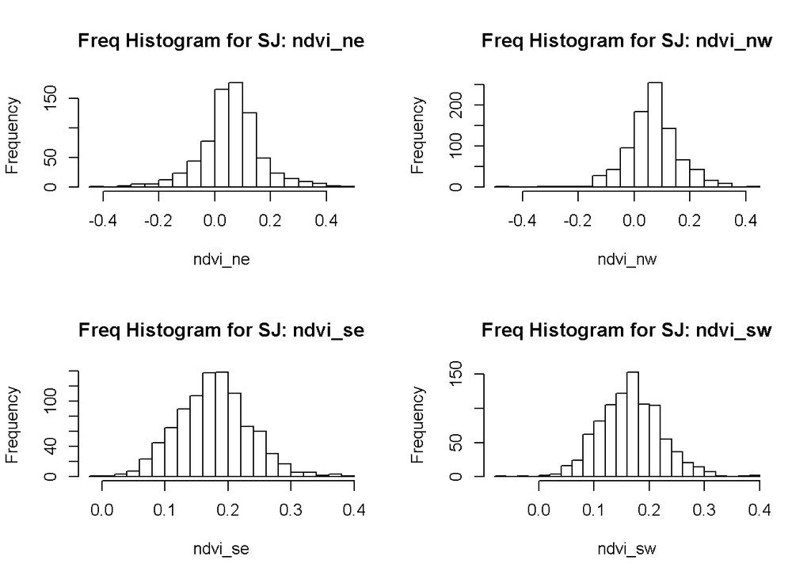

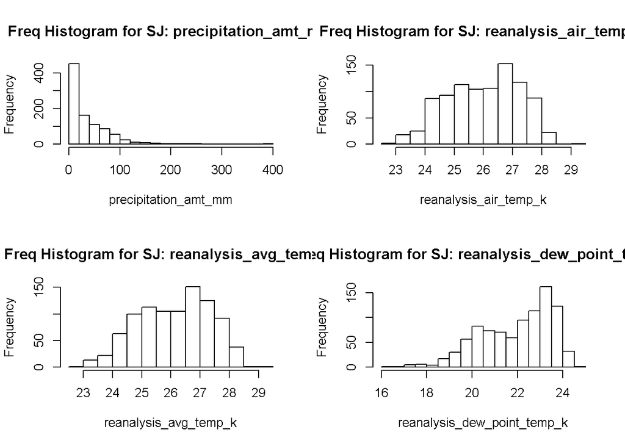

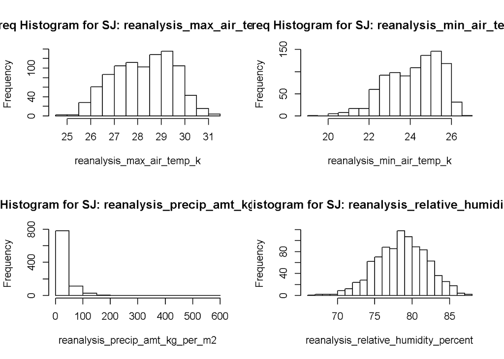

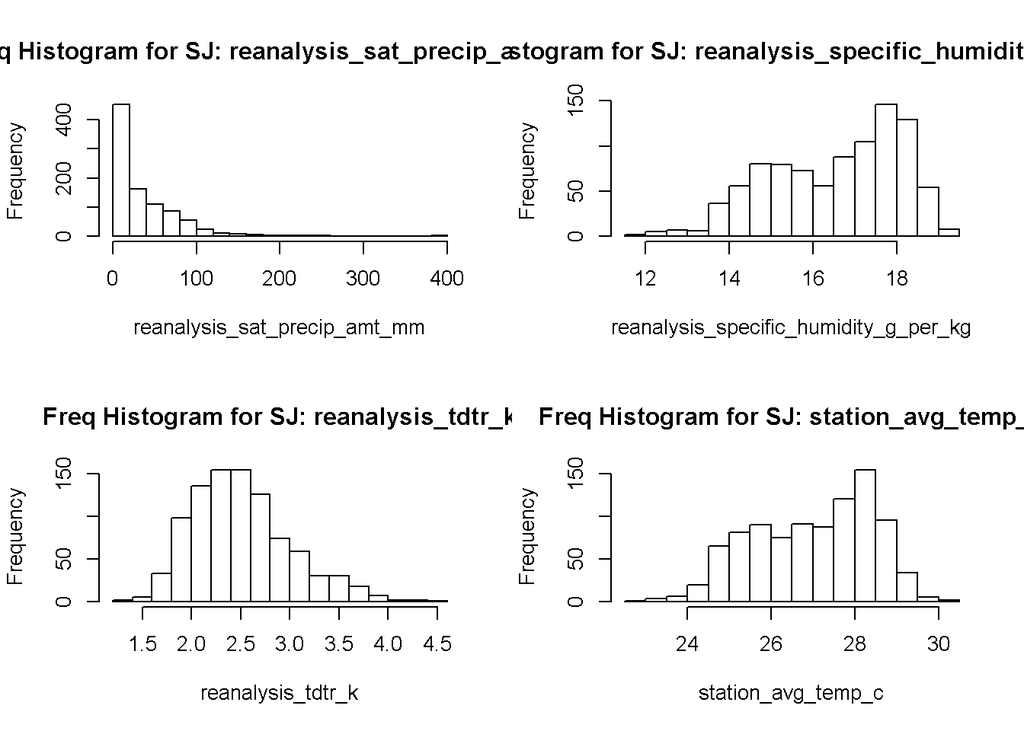

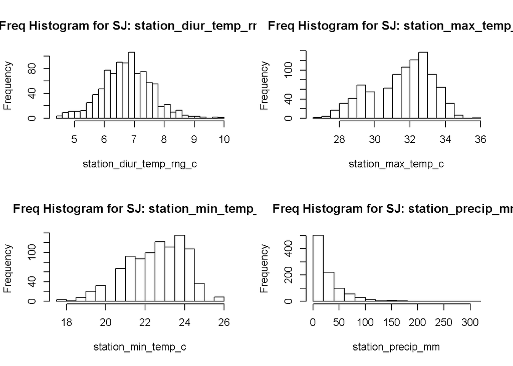

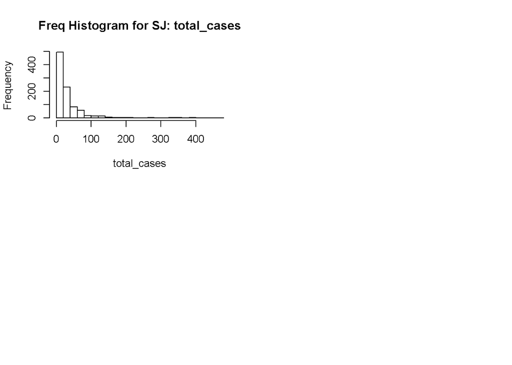

```r
cnames <- colnames(df_train_labels)
par(mfrow=c(2,2))
for (i in 4:ncol(df_train_labels)) {
 hist(df_train_labels[df_train_labels$city == "sj",i],
      breaks = 20,
      xlab = cnames[i],
      main = paste("Freq Histogram for SJ", cnames[i], sep = ": "))
}
```

### GRAPH: Frequency histogram of all variables in training set for **IQ**

Same as above but only for IQ.

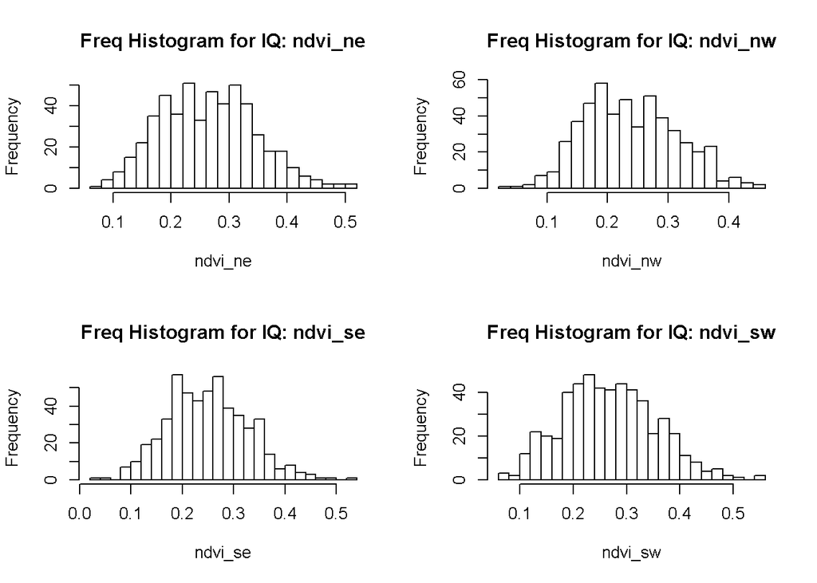

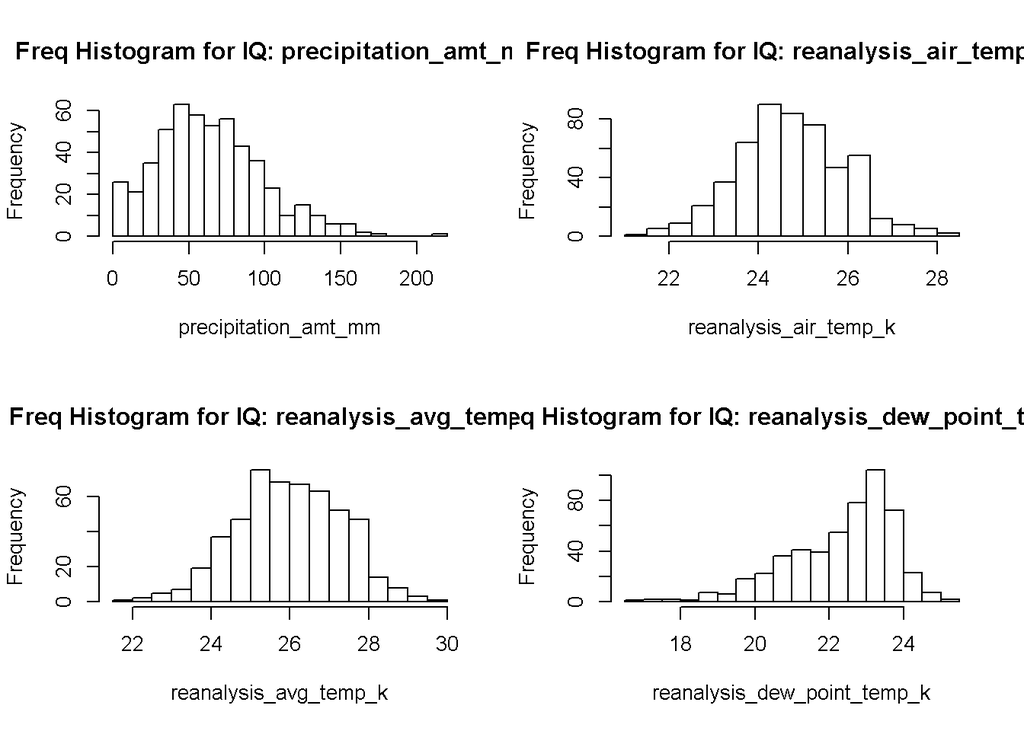

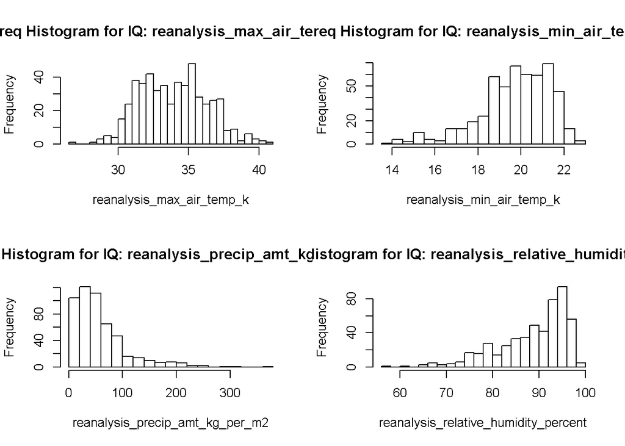

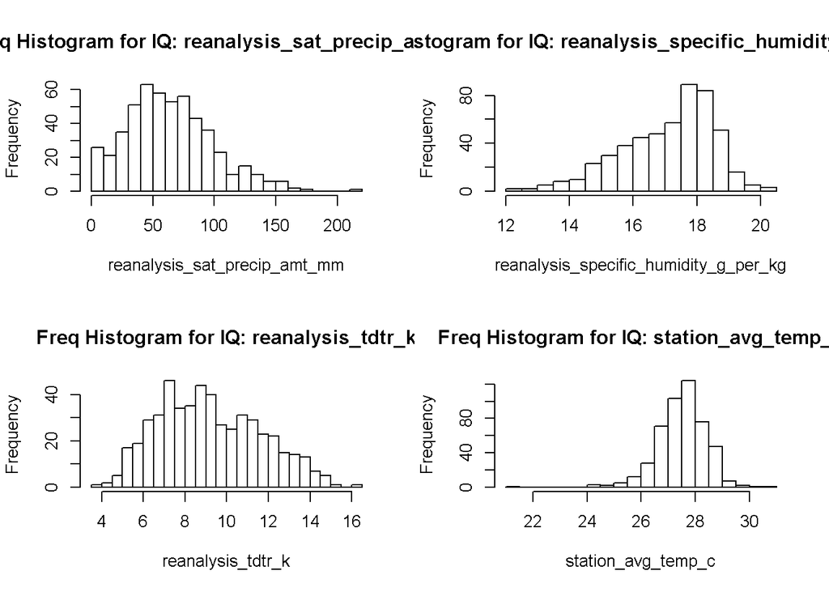

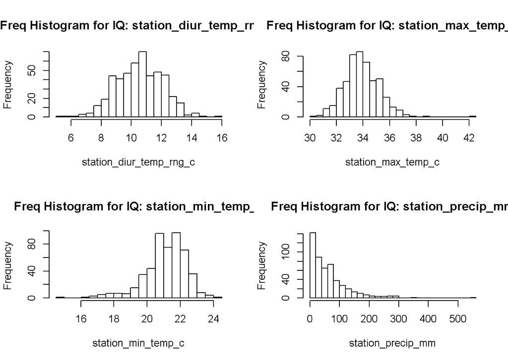

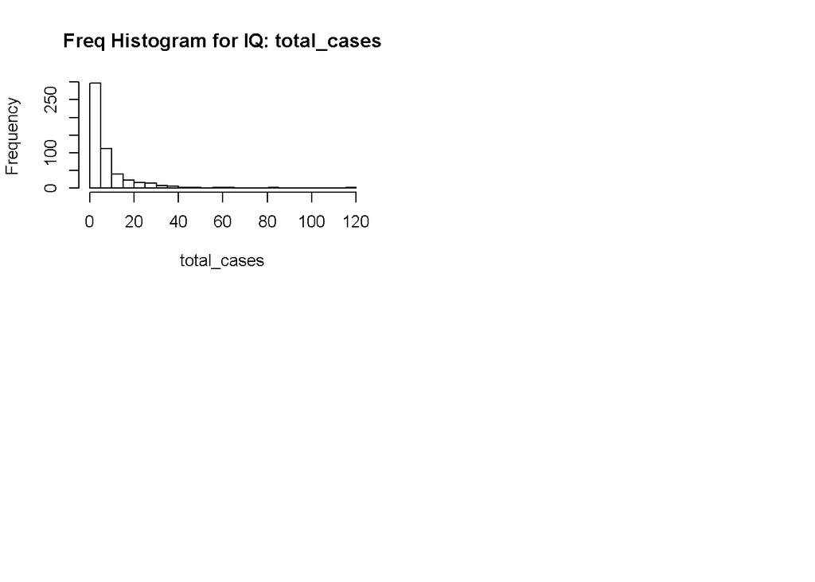

```r
cnames <- colnames(df_train_labels)
par(mfrow=c(2,2))
for (i in 4:(ncol(df_train_labels))) {
 hist(df_train_labels[df_train_labels$city == "iq",i],
      breaks = 20,
      xlab = cnames[i],
      main = paste("Freq Histogram for IQ", cnames[i], sep = ": "))
}
```

### GRAPH: Climate variables by time for **SJ**

Includes all the data from test and training set by time for SJ therefore the total_cases in not included. Total_cases by time is done separately.

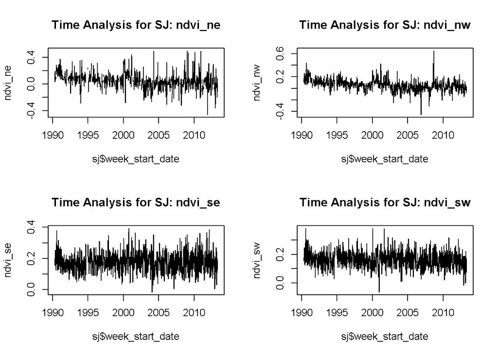

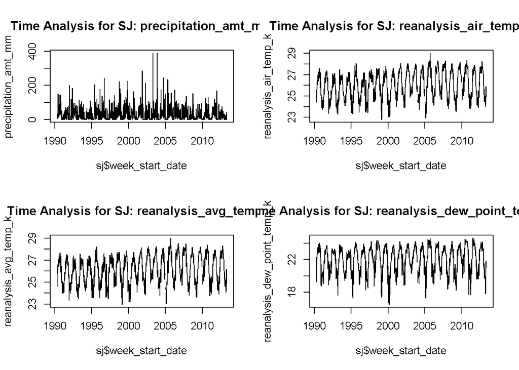

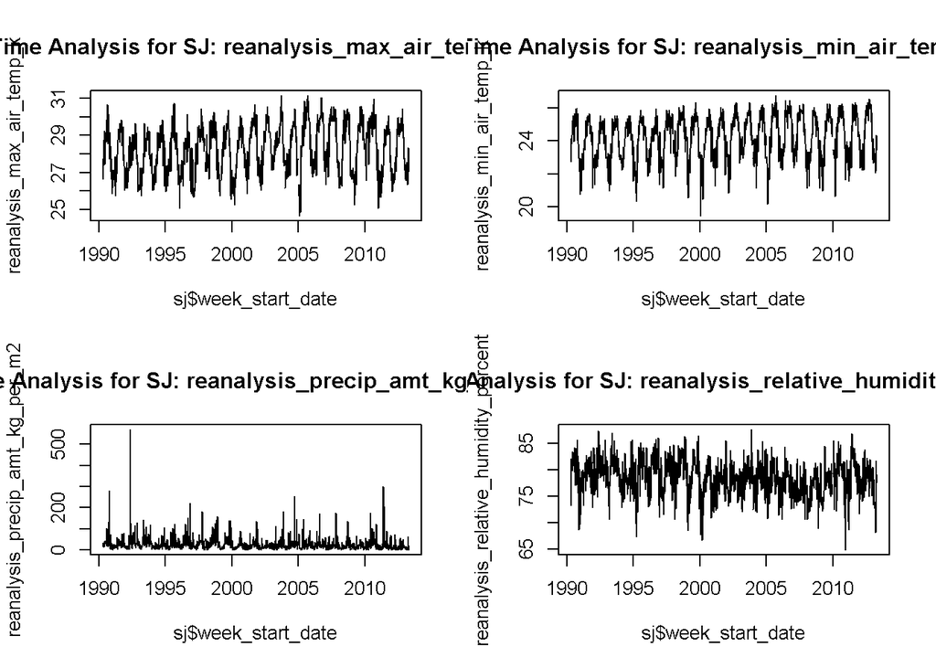

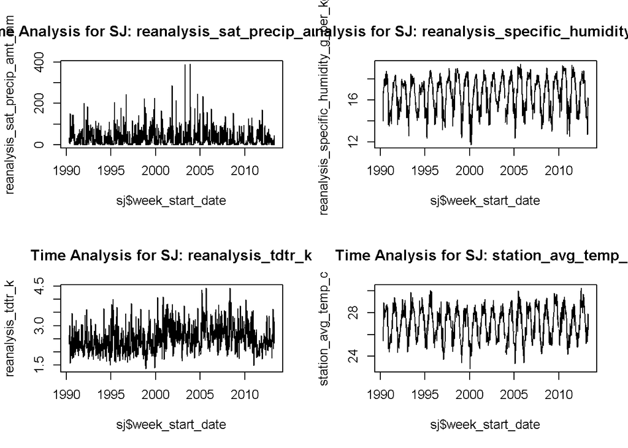

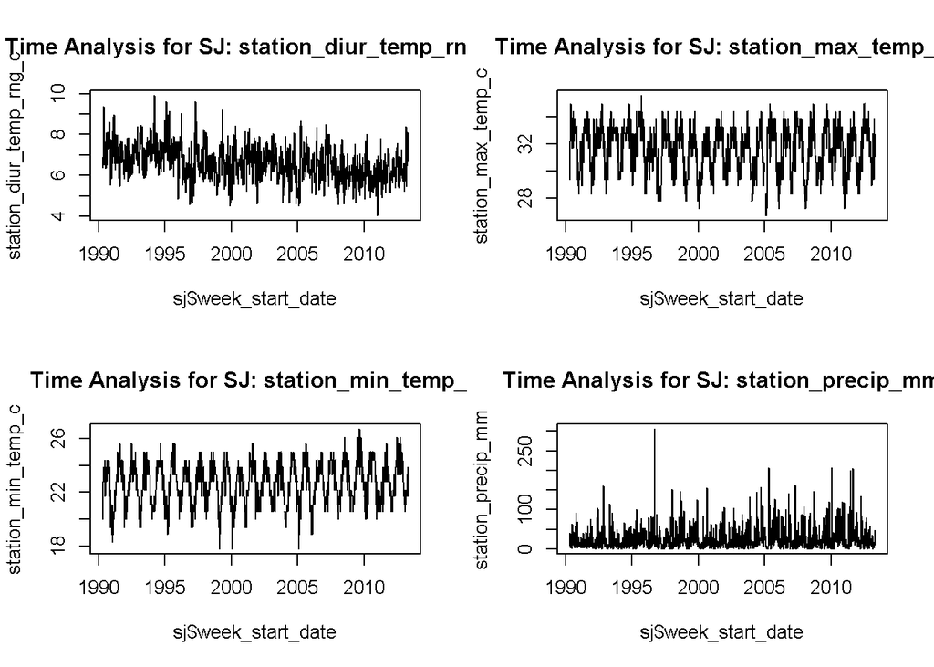

```r
cnames <- colnames(sj)
par(mfrow=c(2,2))
for (i in 5:(ncol(sj))) {
 plot(sj$week_start_date,sj[,i],
      type = "n",
      ylim = c(min(sj[,i],na.rm=TRUE), max(sj[,i],na.rm=TRUE)),
      ylab = cnames[i],
      main = paste("Time Analysis for SJ", cnames[i], sep = ": "))
 lines(sj$week_start_date,sj[,i])
}
```

### GRAPH: Climate variables by time for **IQ**

Includes all the data from test and training set by time for I therefore the total_cases in not included. Total_cases by time is done separately.

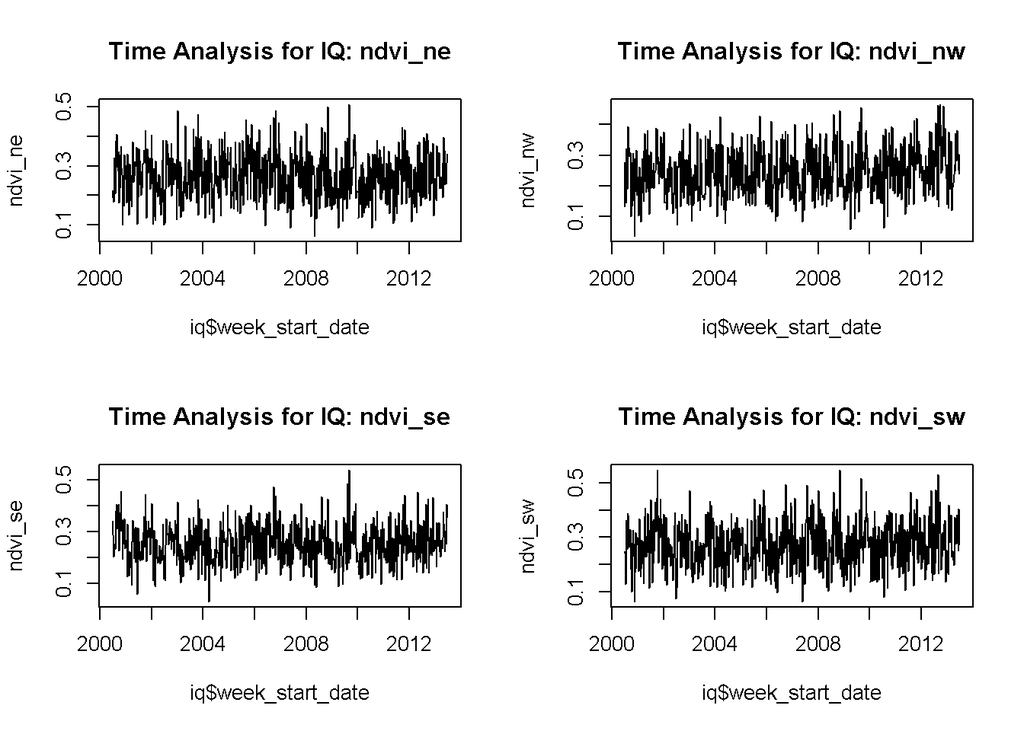

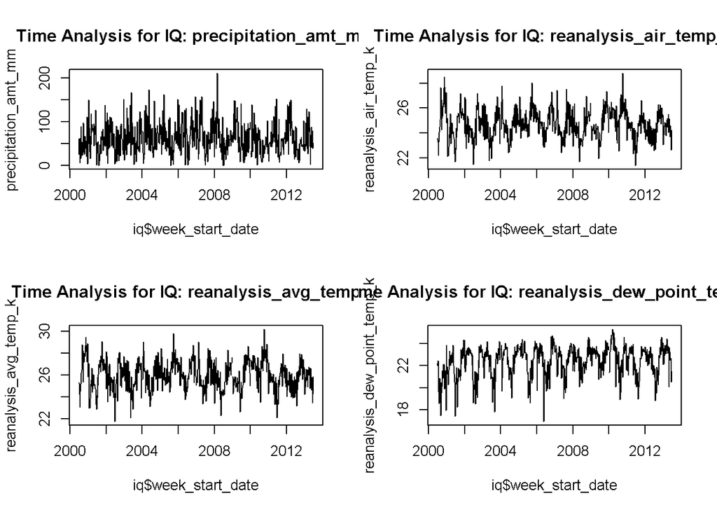

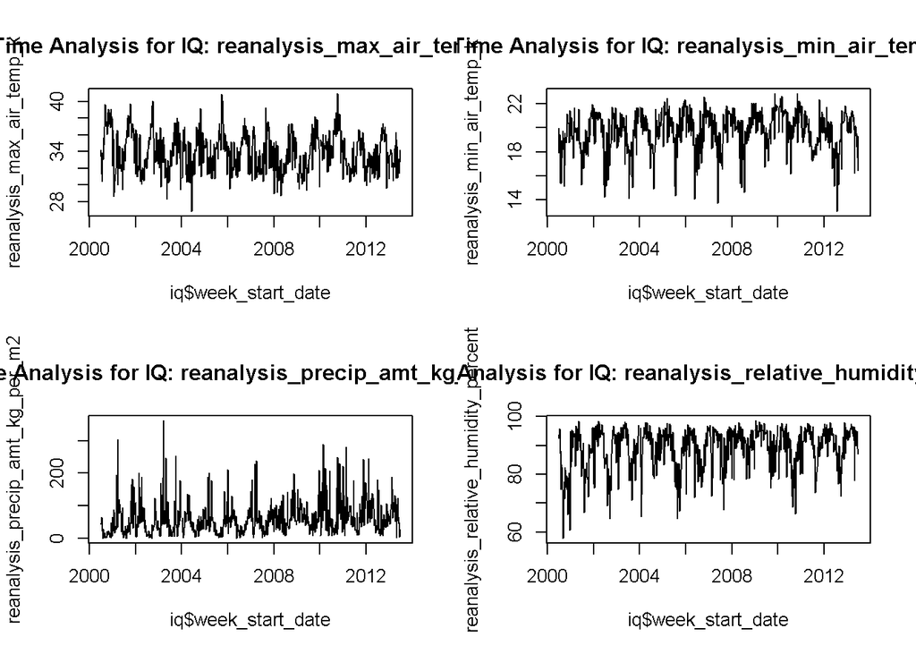

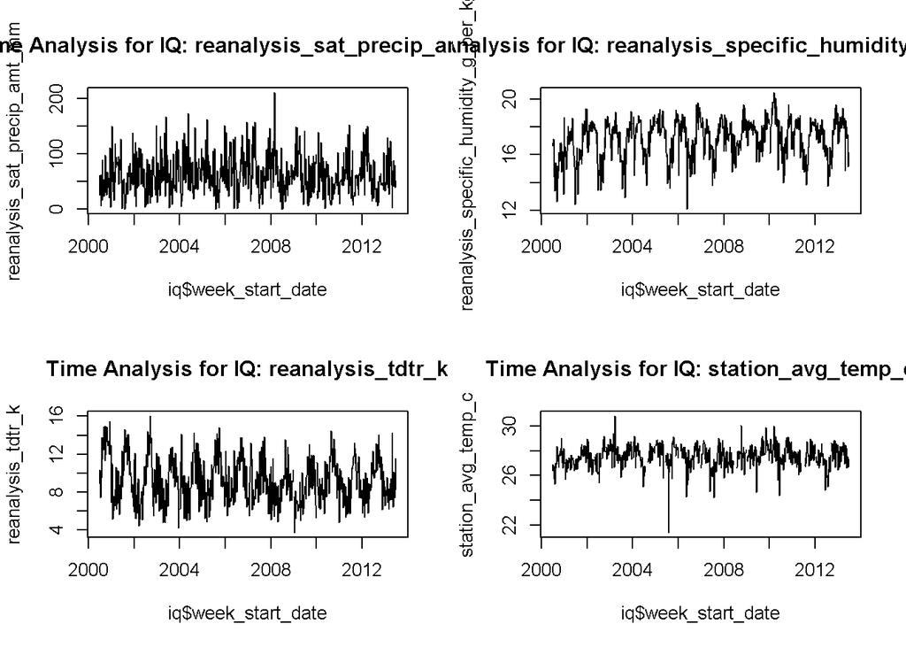

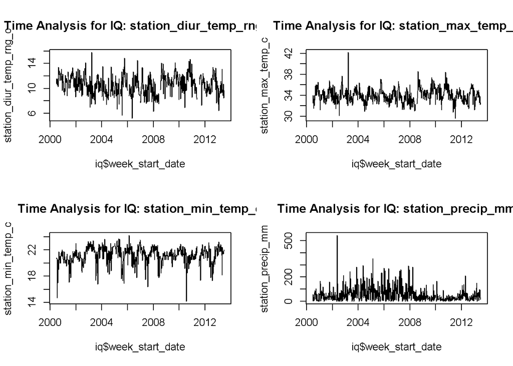

```r
cnames <- colnames(iq)
par(mfrow=c(2,2))
for (i in 5:(ncol(iq))) {
 plot(iq$week_start_date,iq[,i],
      type = "n",
      ylim = c(min(iq[,i],na.rm=TRUE), max(iq[,i],na.rm=TRUE)),
      ylab = cnames[i],
      main = paste("Time Analysis for IQ", cnames[i], sep = ": "))
 lines(iq$week_start_date,iq[,i])
}
```

### GRAPH: Total_cases by time for **SJ**, **IQ** and together

Line graph of all data by total cases. This uses only the training set.

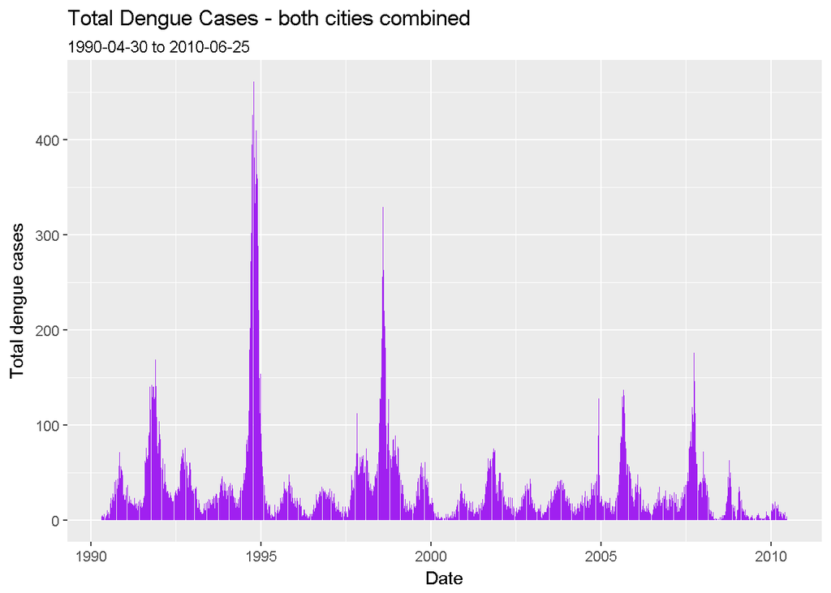

```r
library(ggplot2)
df_train_labels <- merge(dengue_features_train, dengue_labels_train, by=c("city","year","weekofyear"))

par(mfcol=c(1,3))
# Dengue Cases both cities together
ggplot(data = df_train_labels, aes(x=week_start_date, y=total_cases)) +
       geom_bar(stat = "identity", fill = "purple") +
  labs(title = "Total Dengue Cases - both cities combined",
       subtitle = paste(min(df_train_labels$week_start_date),max(df_train_labels$week_start_date), sep = " to "),
       x = "Date", y = "Total dengue cases")
```

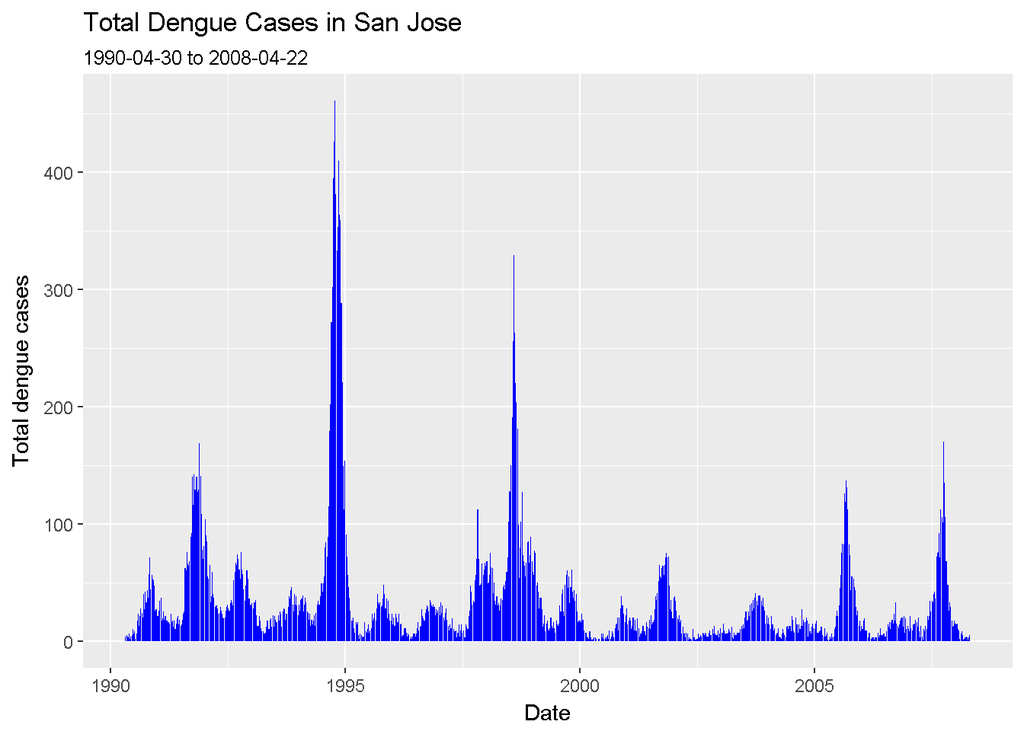

```r
#Dengue Cases for San Jose
ggplot(data = df_train_labels[df_train_labels$city == "sj",], aes(x=week_start_date, y=total_cases)) +
       geom_bar(stat = "identity", fill = "blue") +
  labs(title = "Total Dengue Cases in San Jose",
       subtitle = paste(min(df_train_labels$week_start_date[df_train_labels$city == "sj"]),max(df_train_labels$week_start_date[df_train_labels$city == "sj"]), sep = " to "),
       x = "Date", y = "Total dengue cases")
```

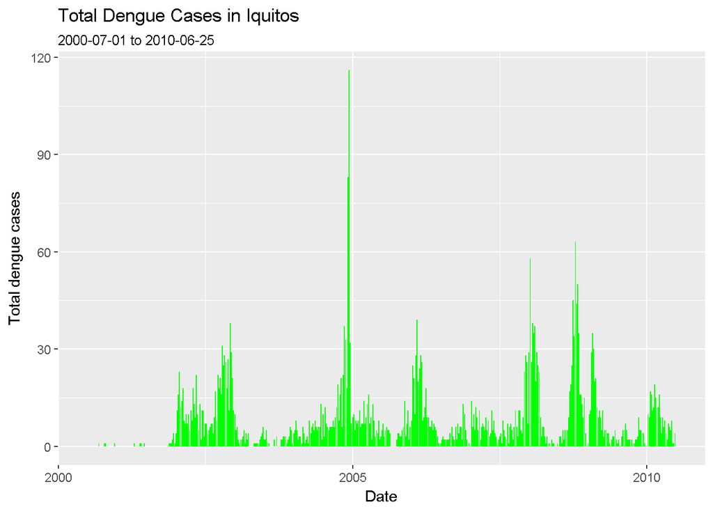

```r
# Dengue Cases for Iquitos
ggplot(data = df_train_labels[df_train_labels$city == "iq",], aes(x=week_start_date, y=total_cases)) +
       geom_bar(stat = "identity", fill = "green") +
  labs(title = "Total Dengue Cases in Iquitos",
       subtitle = paste(min(df_train_labels$week_start_date[df_train_labels$city == "iq"]),max(df_train_labels$week_start_date[df_train_labels$city == "iq"]), sep = " to "),
       x = "Date", y = "Total dengue cases")
```